# Homework 4-5

## **b)Task 2**

I created a time series for the traffic volume in the train object. I made 24 as a frequency because lag 24 was high Acf. Then I created arima_model using the auto.arima function.Summary of this model seen in **table 6**.

I used arima with regressors as another model. I created a regressors matrix for this purpose. The variables I used as regressor were temparature, weekday and holiday effect. The name of this model is reg_arima.Summary of this model seen in **table 7**.

I made predictions for test data using by using these arima models.Plots of my predictions can seen in **figure 8**. Then I created a prediction table and calculated the mse, mad and mape values for both models.These values seen in **table 8**.Since regarima has a smaller mape value it is better than arima model.

## **c)Task 3**

To be able to predict the next 24 hours with the linear model, the regressors of the next 24 hours had to be known. Since the hour effect was repeated every 24 hours, I used the hour effect in my test data. Likewise, the day effect was repeating every 7 days, the holiday effect was repeating every 365 days, and the dayhour effects were recurrent every 168 hours.So I was able to get these effects from my test data.I made a naive forecast for weather_main, weather_descriptiom, temperature and trend and used data from the previous day. I gathered all these regressors in a data table called sontable.I also added information such as hour, date, weekday for the next day in this table. Then, using the information in this table, I made predictions with my lmson, fit3 and fit33 models.Then I made another prediction with arima_model.I have created a matrix for regressors of the next 24 hours.By using these regressors I made my last predictions with reg_arima model. After all I had predictions that I made by using 5 different model.As I mentioned before the first three model was linear,the fourth one is arima and the last one was arima with regressors. Finally, I averaged my predictions using these five different models. I kept my forecasts in the my_forecasts variable.My forecasts can be seen in **table 9**.

### **4.Figures and Tables**

#### Table 1: Summary of first lm model (fit3)

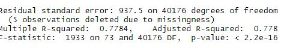

#### Table 2: Summary of second lm model (fit33)

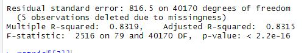

#### Table 3: Summary of lm model for trend

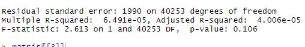

#### Table 4: Summary of third lm model (lmson)

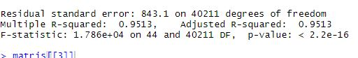

#### Table 5: Error tables for three lm model

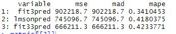

#### Table 6: Summary of first arima model (arima_model)

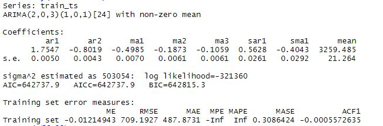

#### Table 7: Summary of arima with regression model (reg_arima)

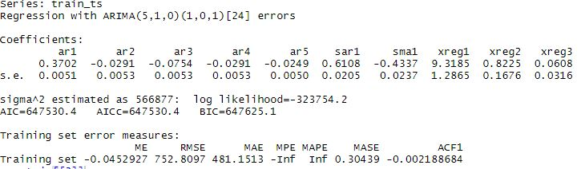

#### Table 8: Error tables of arima models

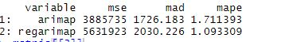

#### Table 9: My forecast for next 24 hours

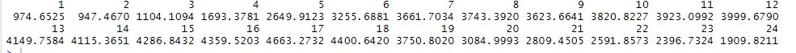

#### **b)Figures**

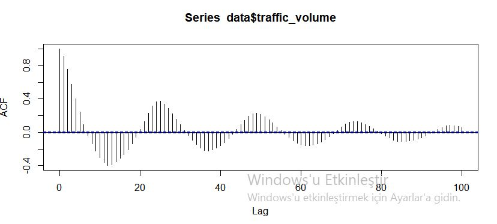

Figure 1: ACF for traffic volume of the data

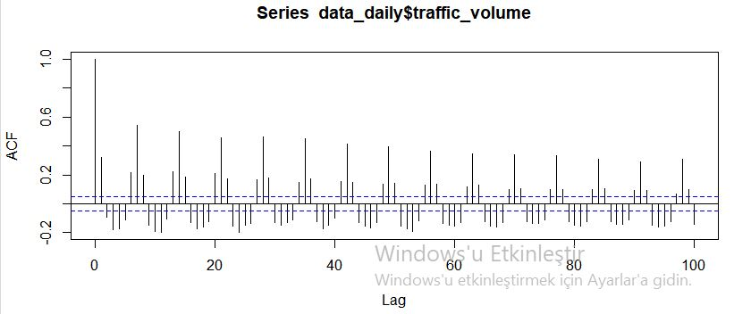

Figure 2: ACF of daily traffic volume

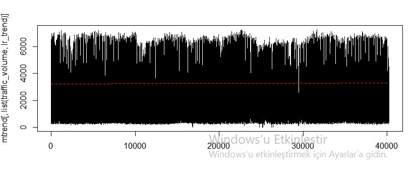

Figure 3: Plot of trend component modeling by linear approach

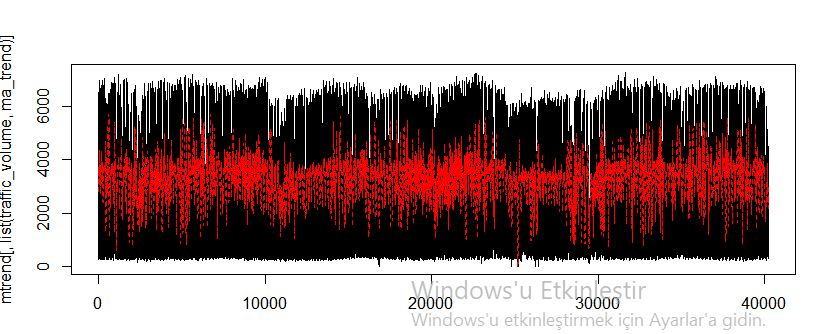

Figure 4: Plot of trend component modeling by moving average approach

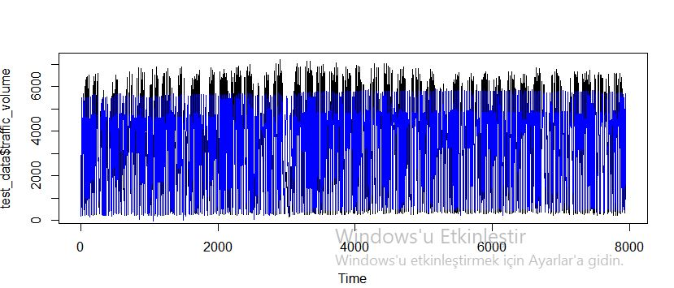

Figure 5: Plot of forecasts of traffic volume for test data by using fit3 model

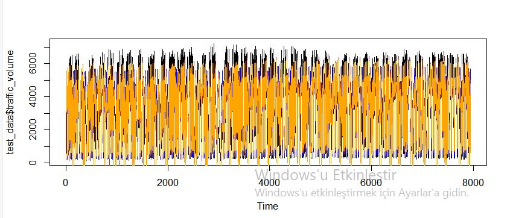

Figure 6: Plot of forecasts of traffic volume for test data by using fit33 model

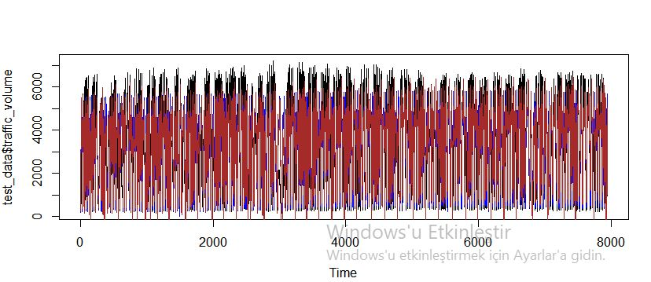

Figure 7: Plot of forecasts of traffic volume for test data by using lmson model

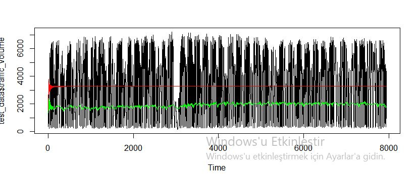

Figure 8: Plot of forecast of traffic volume of test data by using arima_model and reg_arima model

### **5)Appendix**

#### **a)Appendix 1:R Codes for Plotting Figures**

##### Code for Figure 1

```r
acf(data$traffic_volume, lag.max = 100)
```

##### Code for Figure 2

```r
acf(data_daily$traffic_volume, lag.max = 100)
```

##### Code for Figure 3

```r
matplot(mtrend[, list(traffic_volume, lr_trend)], type = "l")
```

##### Code for Figure 4

```r
matplot(mtrend[, list(traffic_volume, ma_trend)], type = "l")
```

##### Code for Figure 5

```r
lines(test_data$fit3pred, col = "blue")
```

##### Code for Figure 6

```r
lines(test_data$fit33pred, col = "orange")
```

##### Code for Figure 7

```r
lines(test_data$lmsonpred, col = "brown")
```

##### Code for Figure 8

```r
ts.plot(test_data$traffic_volume)
lines(test_data$arimap, col = "red")
lines(test_data$regarimap, col = "green")
```

## **6.CODE**

[Here is the github link of the code.](https://github.com/BU-IE-360/ilgazgulsen/blob/master/files/hw4-5.R)

```r
library(data.table)
library(forecast)
library(base)
install.packages(data.table)  #install the required packages
install.packages(forecast)
install.packages("base64")


data = fread("C:/Users/LENOVO/Desktop/trafik.csv", header = TRUE)  #read the data
str(data)


acf(data$traffic_volume, lag.max = 100)  #there is an increase at lag 24 which is a sign for seasonality of hours

data = as.data.table(data)  #convert data to data table
is.data.table(data)
data[, `:=`(date, as.POSIXct(data$date_time, format = "%Y-%m-%d "))]  #seperate date from datetime
str(data)

hour = format(as.POSIXct(data$date_time, format = "%Y-%m-%d %H:%M:%S"),
    "%H")  #seperate hour from datetime
data[, `:=`(hour, (hour))]
str(data)
acf(data$traffic_volume, lag.max = 100)

test_start <- as.Date("2018-01-01")  #starting of test period
test_end <- max(data$date)
numbertest <- 7949

test_data <- data[date > "2017-12-31"]  #seperation of test and train data
train = data[date < "2018-01-01"]

acf(train$traffic_volume, lag.max = 100)
plot(train$traffic_volume)

fit1 <- lm(train$traffic_volume ~ temp + date, train)  # trials of creating an lm model
summary(fit1)
fit <- lm(train$traffic_volume ~ temp + hour + date, train)
summary(fit)
fit2 <- lm(train$traffic_volume ~ temp + hour + date, train)
summary(fit2)
levels(train$holiday)
levels(train$weather_main)
levels(train$weather_description)
train$holiday <- as.factor(train$holiday)  #converting holiday,weather_main,weather_description to factors
train$weather_main <- as.factor(train$weather_main)
train$weather_description <- as.factor(train$weather_description)
str(train)
fit3 <- lm(traffic_volume ~ temp + hour + date + holiday + weather_main +
    weather_description, train)  #first lm model
summary(fit3)




train[, `:=`(c("Year", "Month", "Day"), tstrsplit(date, "-"))]
str(train)
## data[, c('Year','Month','Day'):=lapply(.SD, function(x)
## as.numeric(x)), .SDcols = c('Year','Month','Day')]
str(data)
data_daily = train[, .(traffic_volume = mean(traffic_volume)),
    by = .(Day, Month, Year)]  #creating a daily data
acf(data_daily$traffic_volume, lag.max = 100)  # observing an increase in lag 7 which is sign of daily seasonality
train[, `:=`(weekday, weekdays(date))]

fit33 <- lm(traffic_volume ~ temp + hour + date + holiday + weather_main +
    weather_description + weekday, train)
# Second lm model similar to first lm model but weekday is
# also included
summary(fit33)

# Modeling trend by using linear regression approach
mtrend = train[, list(date_time, traffic_volume, hour)]
mtrend[, `:=`(index, 1:.N)]  #creating an index
str(mtrend)
ltrend <- lm(traffic_volume ~ index, mtrend)  #modeling trend according to index
summary(ltrend)  #not a good r-squared but the positive intercept refers to increasing trend
ltrend_comp <- ltrend$fitted
mtrend[, `:=`(lr_trend, ltrend_comp)]
matplot(mtrend[, list(traffic_volume, lr_trend)], type = "l")

# Modeling trend by using moving average approach
window_size = 12
mtrend[, `:=`(ma_trend, frollmean(traffic_volume, (2 * window_size) +
    1, align = "center"))]
matplot(mtrend[, list(traffic_volume, ma_trend)], type = "l")

matplot(mtrend[, list(traffic_volume, lr_trend, ma_trend)], type = "l")  #linear modeling trend has a better visualization as trend


train[, `:=`(trend, mtrend[, lr_trend])]  # adding trend component to trend data

mtrend[, `:=`(detrendl, traffic_volume - lr_trend)]  #removing trend because it can affects seasonality
mtrend[, `:=`(detrendma, traffic_volume - ma_trend)]

# modeling seasonlity by using moving average approach
mtrend[, `:=`(mahour_effect, mean(detrendma, na.rm = TRUE)),
    by = list(hour)]  #creating hour effect
plot(mtrend$mahour_effect[1:120], type = "l")
mtrend[, `:=`(weekday, train$weekday)]
mtrend[, `:=`(day_effect, mean(detrendma, na.rm = TRUE)), by = list(weekday)]  #creating day effect
plot(mtrend$day_effect[1:200], type = "l")
mtrend[, `:=`(indexses, (index%%168))]
mtrend[, `:=`(dayhour_effect, mean(detrendma, na.rm = TRUE)),
    by = list(indexses)]  #creating day time effect
plot(mtrend$dayhour_effect[1:120], type = "l")
mtrend[, `:=`(holiday, train$holiday)]  #creating holiday effect
mtrend[, `:=`(holiday_effect, mean(detrendma, na.rm = TRUE)),
    by = list(holiday)]
plot(mtrend$dayhour_effect[1:120], type = "l")

train[, `:=`(hour_effect, mtrend$mahour_effect)]  #Adding all seasonality related variables to train data
train[, `:=`(day_effect, mtrend$day_effect)]
train[, `:=`(dayhour_effect, mtrend$dayhour_effect)]
train[, `:=`(holiday_effect, mtrend$holiday_effect)]
# the third lm model
lmson <- lm(traffic_volume ~ -1 + temp + weather_main + weather_description +
    hour_effect + day_effect + dayhour_effect + holiday_effect +
    trend, train)
summary(lmson)  #this model has a good r-squared


# Applying similar procedures and adding similar variables to
# test data
test_data[, `:=`(c("Year", "Month", "Day"), tstrsplit(date, "-"))]
str(test_data)
str(data)
data_daily2 = test_data[, .(traffic_volume = mean(traffic_volume)),
    by = .(Day, Month, Year)]
acf(data_daily$traffic_volume, lag.max = 100)
test_data[, `:=`(weekday, weekdays(date))]


# Modeling trend with linear approach by using test data
mtrend2 = test_data[, list(date_time, traffic_volume, hour)]
mtrend2[, `:=`(index, 1:.N)]
str(mtrend2)
ltrend2 <- lm(traffic_volume ~ index, mtrend2)
summary(ltrend2)
ltrend_comp2 <- ltrend2$fitted
mtrend2[, `:=`(lr_trend2, ltrend_comp2)]
matplot(mtrend2[, list(traffic_volume, lr_trend2)], type = "l")


# Modeling trend with moving average approach by using test
# data
window_size = 12
mtrend2[, `:=`(ma_trend2, frollmean(traffic_volume, (2 * window_size) +
    1, align = "center"))]
matplot(mtrend2[, list(traffic_volume, ma_trend2)], type = "l")

matplot(mtrend2[, list(traffic_volume, lr_trend2, ma_trend2)],
    type = "l")

test_data[, `:=`(trend, mtrend2[, lr_trend2])]
mtrend2[, `:=`(detrendl2, traffic_volume - lr_trend2)]
mtrend2[, `:=`(detrendma2, traffic_volume - ma_trend2)]

# Modeling seasonality with moving average method by using
# test data
mtrend2[, `:=`(mahour_effect2, mean(detrendma2, na.rm = TRUE)),
    by = list(hour)]
plot(mtrend2$mahour_effect2[1:120], type = "l")
mtrend2[, `:=`(weekday, test_data$weekday)]
mtrend2[, `:=`(day_effect, mean(detrendma2, na.rm = TRUE)), by = list(weekday)]
plot(mtrend2$day_effect[1:200], type = "l")
mtrend2[, `:=`(indexses, (index%%168))]
mtrend2[, `:=`(dayhour_effect, mean(detrendma2, na.rm = TRUE)),
    by = list(indexses)]
plot(mtrend2$dayhour_effect[1:120], type = "l")
mtrend2[, `:=`(holiday, test_data$holiday)]
mtrend2[, `:=`(holiday_effect, mean(detrendma2, na.rm = TRUE)),
    by = list(holiday)]
plot(mtrend$dayhour_effect[1:120], type = "l")
# adding seasonality related variables to test data
test_data[, `:=`(hour_effect, mtrend2$mahour_effect2)]
test_data[, `:=`(day_effect, mtrend2$day_effect)]
test_data[, `:=`(dayhour_effect, mtrend2$dayhour_effect)]
test_data[, `:=`(holiday_effect, mtrend2$holiday_effect)]
```

```r
# Making predictions of test data by using these three model

p <- predict(fit3, test_data)
r <- predict(lmson, test_data)
s <- predict(fit33, test_data)
p[1:24]
r[1:24]
test_data[, `:=`(fit3pred, p)]
test_data[, `:=`(lmsonpred, r)]
test_data[, `:=`(fit33pred, s)]
ts.plot(test_data$traffic_volume)  #visualization of predictions and real values
lines(test_data$fit3pred, col = "blue")
lines(test_data$lmsonpred, col = "brown")
lines(test_data$fit33pred, col = "orange")
# calculating mse,mad,mape
pred_table = test_data[, .(date_time, traffic_volume, fit3pred,
    lmsonpred, fit33pred)]
melted = melt(pred_table, id.vars = c(1, 2), na.rm = TRUE)
result = melted[, list(se = (value - traffic_volume)^2, mse = (value -
    traffic_volume)^2, ape = abs(value - traffic_volume)/traffic_volume,
    traffic_volume), by = list(date_time, variable)]
result = result[, list(mse = mean(se, na.rm = TRUE), mad = mean(mse,
    na.rm = TRUE), mape = mean(ape, na.rm = TRUE)), by = list(variable)]
result



# Arima

train_ts <- ts(train[, c("traffic_volume")], frequency = 24)  #creating an ts object
arima_model <- auto.arima(train_ts)  #modeling this time series object by using arima (first arima model)
summary(arima_model)
checkresiduals(arima_model)
arimamodel_fitted <- train_ts - residuals(arima_model)
ts.plot(train_ts)
points(arimamodel_fitted, col = "blue")
prediction <- forecast(arima_model, h = 24)
plot(prediction)

ara <- test_data[1:24, ]
ara <- as.data.table(ara)
ara[, `:=`(arima_prediction, as.vector(prediction$mean))]
ts.plot(ara$traffic_volume)
lines(ara$arima_prediction, col = "blue")
ts2 <- ts(train[, c("traffic_volume")])


matris3 <- as.data.table(train[, c("temp", "day_effect", "holiday_effect")])  #creating a matrix for regressors
nrow(matris3)
z_mat1 <- as.matrix(matris3)
z_mat <- matrix(unlist(z_mat1), nrow = 40255)

matris2 <- matrix(test_data[, c("temp", "day_effect", "holiday_effect")])  #creating a matrix for regressors of test data
str(matris)
z_mat2 <- matrix(unlist(matris2), nrow = 7949)



reg_arima <- auto.arima(train_ts, xreg = as.matrix(z_mat))  # Arima model with regressors(second arima model)
summary(reg_arima)
checkresiduals(reg_arima)
arimareg_fitted <- train_ts - residuals(reg_arima)
ts.plot(train_ts)
points(arimareg_fitted, type = "l")

regpredicted <- forecast(reg_arima, h = 24, xreg = as.matrix(z_mat2))
plot(regpredicted)
test_data[, `:=`(predictreg, as.vector(regpredicted$mean))]
ts.plot(test_data$traffic_volume)
lines(test_data$predictreg, col = "red")

k = forecast(arima_model, h = 7949)  #forecasting with first arima model
l = forecast(reg_arima, h = 7949, xreg = as.matrix(z_mat2))  #forecasting with second arima model

test_data[, `:=`(arimap, as.vector(k$mean))]
test_data[, `:=`(regarimap, as.vector(l$mean))]
ts.plot(test_data$traffic_volume)
lines(test_data$arimap, col = "red")
lines(test_data$regarimap, col = "green")
# calculatin mse,mad,mape for these two arima models
pred2 = test_data[, .(date_time, traffic_volume, arimap, regarimap)]
melted2 = melt(pred2, id.vars = c(1, 2), na.rm = TRUE)
res2 = melted2[, list(se = (value - traffic_volume)^2, ad = abs(value -
    traffic_volume), ape = abs(value - traffic_volume)/traffic_volume,
    traffic_volume), by = list(date_time, variable)]

res2 = res2[, list(mse = mean(se, na.rm = TRUE), mad = mean(ad,
    na.rm = TRUE), mape = mean(ape, na.rm = TRUE)), by = list(variable)]
res2


## task 3
sontable <- data.table()
houref <- test_data[, "hour_effect"]  #since hour effect repeats every 24 hour
phour <- houref[1:24]
sontable[, `:=`(hour_effect, phour)]
dayef <- test_data[, "day_effect"]  #day effects repeats every week and my prediction will be monday so I take the effect of monday
pday <- dayef[1:24]
sontable[, `:=`(day_effect, pday)]
dayhouref <- test_data[, "dayhour_effect"]  #day hour effects repeat every 168 hour
dayhef <- dayhouref[1:24]
sontable[, `:=`(dayhour_effect, dayhef)]
holidayef <- test_data[, "holiday_effect"]
phol <- holidayef[2:25]
# since the date that will made prediction is not holiday
# effect equal to none holiday effect
sontable[, `:=`(holiday_effect, phol)]
# naive forecast has been made for the
# temperature,weather_main,weather_description,trend
te <- test_data[, "temp"]
ptemp <- te[7926:7949]
sontable[, `:=`(temp, ptemp)]  #temperature of day before the forecast day
wem <- test_data[, "weather_main"]
pwem <- wem[7926:7949]
sontable[, `:=`(weather_main, pwem)]  #weather main of the day before the forecast day
wed <- test_data[, "weather_description"]
pwed <- wed[7926:7949]
sontable[, `:=`(weather_description, pwed)]  #weather description of the day before the forecast day
tred <- test_data[, "trend"]
ptrend <- tred[7926:7949]
sontable[, `:=`(trend, ptrend)]  #trend of the day before forecast day
ptr <- test_data[, "traffic_volume"]
ptraff <- ptr[7926:7949]
sontable[, `:=`(traffic_volume, ptraff)]


phour2 <- test_data[, "hour"]
p32 <- phour2[7926:7949]
sontable[, `:=`(hour, p32)]  #adding hour information
pholiday2 <- test_data[, "holiday"]
h32 <- pholiday2[7926:7949]
sontable[, `:=`(holiday, h32)]  #adding holiday information
tar2 <- as.Date("2018-10-01")
tar32 <- rep(tar2, 24)
sontable[, `:=`(date, tar32)]
sontable[, `:=`(weekday, "Pazartesi")]  #adding weekday information

pa1 <- predict(lmson, sontable)  #prediction with the third lm model
pa2 <- predict(fit3, sontable)  #prediction with the first lm model
pa3 <- predict(fit33, sontable)  #prediction with the second lm model

ts3 <- ts(sontable[, "traffic_volume"])


pp4 <- forecast(arima_model, h = 24)
pa4 <- as.vector(pp4$mean)  #prediction with the first arima model

matris3 <- matrix(sontable[, c("temp", "day_effect", "holiday_effect")])  #creating a matrix for regressors of forecast data
str(matris3)
matris3 < as.numeric(matris3)
z_mat3 <- matrix(unlist(matris3), nrow = 24)

pp5 <- forecast(reg_arima, h = 24, xreg = as.matrix(z_mat3))
pa5 <- as.vector(pp5$mean)  #prediction with the second arima model


myfor <- pa1 + pa2 + pa3 + pa4 + pa5
my_forecasts <- myfor/5  #average of predictions of these 5 model
my_forecasts  #my forecasts
```